# COVID-19 Model Fitting and Forecasting Report

Andrew Tredennick, Andreas Handel, and John Drake

15 April, 2020

```r
library(pomp)
library(tidyverse)
library(here)
```

## Data

We use data on confirmed cases, hospitalizations, and deaths from [The Covid Tracking Project](https://covidtracking.com/).

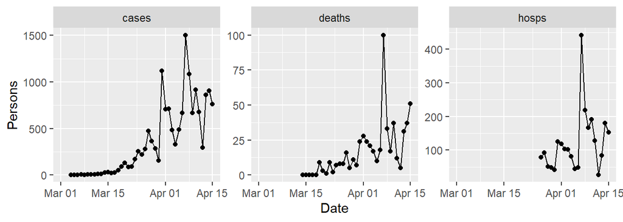

```r
# Load covid tracking data
us_data <- read_csv("https://covidtracking.com/api/states/daily.csv")

# Load state population sizes
filename = here('data/us_popsize.rds')
us_popsize <- readRDS(filename)

# Rename columns and comvert to daily counts with diff()
us_clean <- us_data %>%
  dplyr::select(c(date,state,positive,negative,total,hospitalized,death)) %>%
  mutate(date = as.Date(as.character(date),format="%Y%m%d")) %>%
  group_by(state) %>% arrange(date) %>%
  mutate(Daily_Test_Positive = c(0,diff(positive))) %>%
  mutate(Daily_Test_Negative = c(0,diff(negative))) %>%
  mutate(Daily_Test_All = c(0,diff(total))) %>%
  mutate(Daily_Hospitalized = c(NA,diff(hospitalized))) %>%
  mutate(Daily_Deaths = c(NA,diff(death))) %>%
  merge(us_popsize) %>%
  rename(Date = date, Location = state_full, Population_Size = total_pop,
         Total_Deaths = death,Total_Cases = positive,
         Total_Hospitalized = hospitalized, Total_Test_Negative = negative,
         Total_Test_Positive = positive, Total_Test_All = total) %>%
  mutate(Daily_Cases = Daily_Test_Positive,
         Total_Cases = Total_Test_Positive) %>%
  select(-c(state,Total_Test_Negative,Daily_Test_Negative))

# This bit of code is to get columns names to align with
# what's currently in the pomp code
us_ct_clean <- us_clean %>%
  rename(cases = Daily_Cases,
         hosps = Daily_Hospitalized,
         deaths = Daily_Deaths)

# Extract Georgia data
pomp_data <- us_ct_clean %>%
  dplyr::filter(Location == "Georgia") %>%
  dplyr::select(Date, cases, hosps, deaths) %>%
  dplyr::arrange(Date)

# Make a pseudo data frame to include all dates from March 1 to now
pseudo_data <- data.frame(
    Date = seq.Date(from = as.Date("2020-03-01"), to = Sys.Date(), by = "day"),
    hold = NA)

# Merge in the NAs to complete the time series
pomp_data <- pomp_data %>%
  right_join(pseudo_data, by = "Date") %>%
  dplyr::select(-hold) %>%
  mutate(time = 1:n()) %>%
  dplyr::select(Date, time, cases, hosps, deaths)

# Plot the data to date
pomp_data %>%
  dplyr::select(-time) %>%
  gather(key = "Observation", value = "Persons", -Date) %>%
  ggplot(aes(x = Date, y = Persons)) +
  geom_line() +
  geom_point() +
  facet_wrap(~Observation, scales = "free_y")
```

We also use data on traveling distance as a metric of social distancing. It is a relative metric ($\phi(t)$) that we assume linearly impacts the force of infection, such that the force of infection at time *t*, $f(t)$, is reduced to: $\phi(t) \times f(t)$. Here is $\phi(t)$ over time.

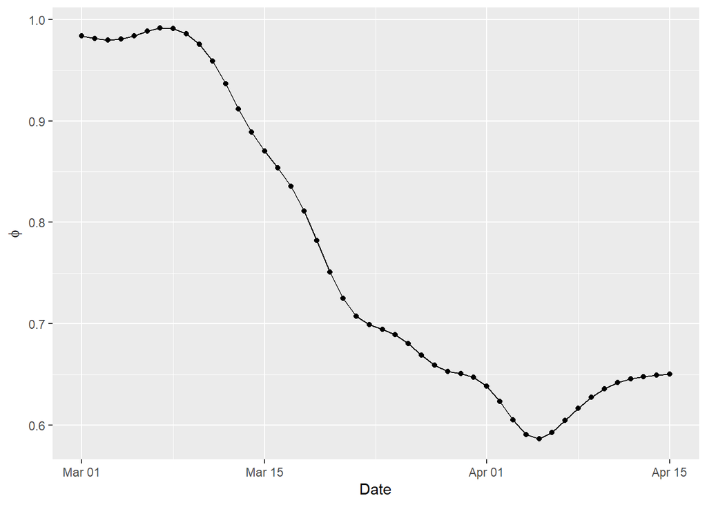

```r
phi <- readRDS("../output/rel-beta-change-covar.RDS") %>%
  left_join(pomp_data %>%
              dplyr::select(Date, time), by = "time")

ggplot(data = phi, aes(x = Date, y = rel_beta_change)) +
  geom_line() +
  geom_point() +
  ylab(expression(phi))
```

## Iterated filtering

We start the estimation procedure by using iterated filtering to find the maximum likelihood parameter estimates. We use the `pomp::mif2()` function. Here are the results from MIF iterations started from size different parameter set guesses.

First, we look at the trace plots.

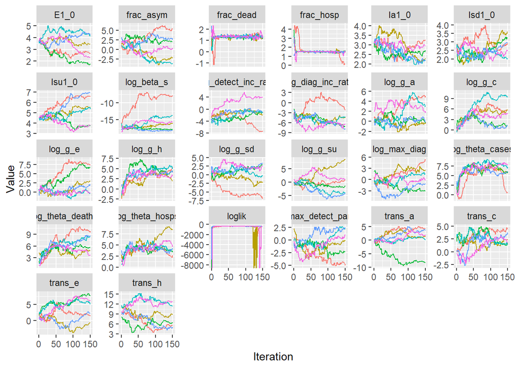

```r
mif_res <- readRDS("../output/mif-results.RDS")
mifs <- mif_res$mif_runs

# Combine the mif runs for plotting
all_mifs <- tibble()  # empty object
for(i in 1:length(mifs)) {
  tmpmif <- mifs[[i]]@traces %>%
    as.data.frame() %>%
    mutate(Iteration = 0:(n()-1)) %>%
    gather(key = "Parameter", value = "Value", -Iteration) %>%
    mutate(MIF_ID = i)

  all_mifs <- bind_rows(all_mifs, tmpmif)
}

# Read in the parameter names we actually estimate
params_to_estimate <- readRDS("../output/var-par-definitions.RDS")
params_to_estimate <- c(params_to_estimate$params_to_estimate,
                        params_to_estimate$inivals_to_estimate,
                        "loglik")

all_mifs <- all_mifs %>%
  filter(Parameter %in% params_to_estimate)

ggplot(all_mifs, aes(x = Iteration, y = Value, color = as.factor(MIF_ID))) +
  geom_line() +
  facet_wrap(~Parameter, scales = "free_y") +
  guides(color = FALSE)
```

We can also look at the log likelihoods of the estimated parameter sets.

```r
pfs <- mif_res$pf_runs
n_ini_cond = length(mifs)
ll = list()
for (i in 1:n_ini_cond) #do last part not in parallel
{
  ll1 <- sapply(pfs[[i]], logLik)
  ll[[i]] <- logmeanexp(ll1, se = TRUE)
}
# convert the list containing the log likelihoods for
# each run stored in ll into a data frame
ll_df <- data.frame(matrix(unlist(ll), nrow=n_ini_cond, byrow=T))

# extract best fit paramter values for each mif run
coef_est_df <- data.frame(matrix(unlist(sapply(mifs, coef)),
                               nrow = length(mifs),
                               byrow = T))
colnames(coef_est_df) <- names(coef(mifs[[1]]))


# combine the ll_df and coef_est_df data frames.
# Also do some cleaning/renaming
mif_result_df <- ll_df %>%
  dplyr::rename("LogLik" = X1,
                "LogLik_SE" = X2) %>%
  dplyr::mutate(MIF_ID = 1:n()) %>%
  dplyr::select(MIF_ID, LogLik, LogLik_SE) %>%
  bind_cols(coef_est_df) %>%
  dplyr::arrange(-LogLik)

knitr::kable(mif_result_df)
```

| MIF_ID | LogLik | LogLik_SE | log_beta_s | trans_e | trans_a | trans_c | trans_h | log_g_e | log_g_a | log_g_su | log_g_sd | log_g_c | log_g_h | log_max_diag | log_diag_inc_rate | max_detect_par | log_detect_inc_rate | frac_asym | frac_hosp | frac_dead | log_theta_cases | log_theta_hosps | log_theta_deaths | S_0 | E1_0 | Ia1_0 | Isu1_0 | Isd1_0 | C1_0 | … |
| --- | --- | --- | --- | --- | --- | --- | --- | --- | --- | --- | --- | --- | --- | --- | --- | --- | --- | --- | --- | --- | --- | --- | --- | --- | --- | --- | --- | --- | --- | --- |
| 3 | -372.2327 | 4.1840800 | -17.900091 | 7.8649130 | -8.3195914 | 1.551599 | 6.414140 | 6.6945660 | -0.1448077 | -1.2846732 | 2.8137361 | 1.329025 | 4.473161 | -3.0345561 | -7.105316 | -2.2517658 | -1.134342 | 2.0031942 | 1.4803488 | 1.333563 | 5.6808329 | 3.514237 | 5.682552 | 10600000 | 1.777377 | 2.707924 | 3.813214 | 3.229440 | 2 | … |
| 2 | -408.3267 | 4.9585343 | -16.039250 | -0.7695215 | 1.2742840 | 2.377857 | 8.760186 | 3.0338650 | -0.2272624 | 8.4092159 | -2.2770507 | 5.912502 | 2.001171 | 2.6936298 | -4.244960 | 0.0664921 | -1.732172 | -2.3408130 | 1.4742271 | 1.224410 | 5.7298231 | 8.493969 | 4.781753 | 10600000 | 3.445991 | 2.312159 | 5.600608 | 3.589164 | 2 | … |
| 4 | -424.3595 | 1.0291684 | -13.819342 | 5.1128255 | 0.2715369 | 1.387233 | 11.526549 | -0.4720260 | 3.0648172 | -4.1083707 | -0.2172796 | 9.723590 | 5.130525 | 1.5984657 | -4.427358 | 2.1564381 | -1.066137 | -3.7946459 | 1.4987879 | 1.262730 | 6.8678376 | 4.147522 | 8.297015 | 10600000 | 4.129565 | 2.164093 | 5.377562 | 2.045813 | 2 | … |
| 1 | -562.0254 | 0.6296456 | -8.042166 | 1.4181645 | 4.2279442 | 4.533996 | 5.497448 | 7.4702354 | 5.0561551 | 0.7149392 | -7.0196179 | 5.873334 | 5.339630 | 5.4902772 | -2.163314 | -4.9518188 | -7.162299 | 5.4372008 | 0.1219608 | 1.404539 | 0.6820047 | 2.621192 | 9.489279 | 10600000 | 2.684967 | 3.238778 | 6.628718 | 2.921181 | 2 | … |
| 5 | -2009.4434 | 19.0444704 | -18.289036 | 2.2394862 | 3.8982067 | 3.772801 | 5.053702 | 1.9107279 | -0.2197649 | -4.3046207 | 3.5354714 | 1.303564 | 4.303637 | -1.1019495 | -7.675073 | 2.4203964 | -1.019385 | 2.4595247 | 1.4691253 | 1.439619 | 6.1399090 | 4.148978 | 8.630465 | 10600000 | 4.267654 | 2.215894 | 6.919284 | 2.950682 | 2 | … |
| 6 | -3472.8947 | 159.7545054 | -15.724664 | 6.1309090 | 2.1722027 | 1.793384 | 12.651159 | -0.1441995 | 1.7363055 | 1.2103540 | 2.6364650 | 4.876834 | 3.297964 | -0.1059077 | -6.440657 | 0.9883169 | 4.114723 | 0.3590812 | 1.4696800 | 1.361819 | 7.6603070 | 4.561534 | 3.790721 | 10600000 | 2.295745 | 2.937755 | 3.806496 | 2.461711 | 2 | … |

Those parameter sets are on the esimation scales. We can backtransform the highest likelihood parameter set for inspection.

```r
backtransform <- function(param_df) {
  out <- length(nrow(param_df))
  for(i in 1:nrow(param_df)) {
    trans <- param_df[i,"trans"]
    x <- param_df[i,"value"]
    if(trans == "log") {
      out[i] <- exp(x)
    } else {
      out[i] <- 1/(1+exp(x))
    }
  }
  return(out)
}

param_names <- c("log_beta_s", "trans_e", "trans_a", "trans_c", "trans_h",
                 "log_g_e", "log_g_a", "log_g_su", "log_g_sd", "log_g_c", "log_g_h",
                 "log_max_diag", "log_diag_inc_rate", "max_detect_par",
                 "log_detect_inc_rate", "frac_asym", "frac_hosp", "frac_dead",
                 "log_theta_cases", "log_theta_hosps", "log_theta_deaths",
                 "log_sigma_dw", "E1_0", "Ia1_0", "Isu1_0", "Isd1_0")

param_trans <- c("log", "logis", "logis", "logis", "logis",
                 "log", "log", "log", "log", "log", "log",
                 "log", "logis", "logis",
                 "log", "logis", "logis", "logis",
                 "log", "log", "log",
                 "log", "log", "log", "log", "log")

param_df <- data.frame(param_name = param_names,
                       trans = param_trans)

ests <- mif_result_df %>%
  filter(LogLik == max(LogLik)) %>%
  dplyr::select(-MIF_ID, -LogLik, -LogLik_SE) %>%
  as.data.frame() %>%
  gather(key = "param_name")

param_df <- param_df %>%
  left_join(ests)
param_df$transforms <- backtransform(param_df)
param_df$transforms[param_df$param_name == "log_beta_s"] <- param_df$transforms[param_df$param_name == "log_beta_s"]*10600018


param_df$transforms <- round(param_df$transforms,3)
comparment_rates <- c("log_g_e", "log_g_a", "log_g_su",
                      "log_g_sd", "log_g_c", "log_g_h")
param_df <- param_df %>%
  mutate(transforms = ifelse(param_name %in% comparment_rates, transforms/4, transforms))

param_df[ , c("param_name", "transforms")] %>% deframe() %>% knitr::kable()
```

|  | x |
| --- | --- |
| log_beta_s | 0.17800 |
| trans_e | 0.00000 |
| trans_a | 1.00000 |
| trans_c | 0.17500 |
| trans_h | 0.00200 |
| log_g_e | 202.00075 |
| log_g_a | 0.21625 |
| log_g_su | 0.06925 |
| log_g_sd | 4.16800 |
| log_g_c | 0.94425 |
| log_g_h | 21.90825 |
| log_max_diag | 0.04800 |
| log_diag_inc_rate | 0.99900 |
| max_detect_par | 0.90500 |
| log_detect_inc_rate | 0.32200 |
| frac_asym | 0.11900 |
| frac_hosp | 0.18500 |
| frac_dead | 0.20900 |
| log_theta_cases | 293.19400 |
| log_theta_hosps | 33.59000 |
| log_theta_deaths | 293.69800 |
| log_sigma_dw | NA |
| E1_0 | 5.91400 |
| Ia1_0 | 14.99800 |
| Isu1_0 | 45.29600 |
| Isd1_0 | 25.26600 |

## Simulate from the MLEs

The next step is to ensure that the MLEs generate “reasonable” trajectories. This step is a bit subjective, and here inlies the art of modeling and forecasting.

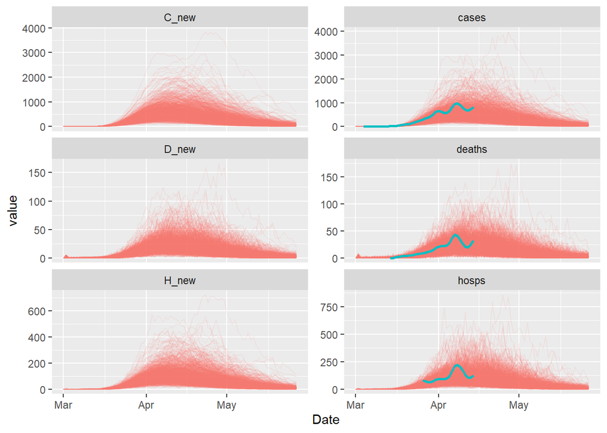

```r
allparvals <- mif_result_df %>%
  filter(LogLik == max(LogLik)) %>%
  dplyr::select(-MIF_ID, -LogLik, -LogLik_SE) %>%
  mutate(log_sigma_dw = log(0.5))

filename <- here('./output/pomp-model.RDS')
pomp_model <- readRDS(filename)

M2 <- pomp_model  # define new pomp model for simulation
horizon <- 7*6  # days times weeks
time(M2) <- c(time(pomp_model), max(time(pomp_model))+seq_len(horizon))

# Update the covariate table to go into the future
covars <- pomp_model@covar@table
covars <- c(covars, rep(as.numeric(tail(t(covars), 1)), times = horizon))
covars <- as.data.frame(covars) %>%
  mutate(time = 1:n()) %>%
  rename("rel_beta_change" = covars)
M2 <- pomp(M2,
           covar = covariate_table(covars, times = "time", order = "constant"))

# Run simulation a number of times
sims <- pomp::simulate(M2,
                       params=allparvals,
                       nsim=1000, format="data.frame",
                       include.data=TRUE)

# Set up dates for plotting
start_date <- as.Date("2020-03-01")
end_date <- start_date + max(sims$time) - 1
dates <- seq.Date(start_date, end_date, "days")
dates_df <- data.frame(time = c(1:length(dates)), Date = dates)

sims %>%
  left_join(dates_df) %>%
  dplyr::select(Date, .id, C_new, H_new, D_new, cases, hosps, deaths) %>%
  tidyr::gather(key = "variable", value = "value", -Date, -.id) %>%
  mutate(.id = ifelse(.id == "data", "ZZZ", .id)) %>%
  ggplot(aes(x = Date, y = value, group = .id, color=.id=="ZZZ",
             size = .id=="ZZZ", alpha = .id == "ZZZ")) +
  geom_line() +
  facet_wrap(~variable, scales = "free_y", ncol = 2) +
  scale_size_manual(values = c(0.5, 1)) +
  scale_alpha_manual(values = c(0.1, 1)) +
  guides(color = FALSE, size = FALSE, alpha = FALSE) +
  scale_x_date(date_breaks = "1 month", date_labels =  "%b")
```